# Peak overlaps and annotation

Franziska Greulich

2022-08-18

## Peak Overlaps and annotations

### 1. working with multiple BED files

I am using Cut&Tag data from Kaya-Okur et al. 2019, Nature (https://doi.org/10.1038/s41467-019-09982-5) to demonstrate how to handle multiple peak files, how to convert them into a `GRangesList`. Afterwards, we will compute overlaps, visualize them and annotate our peaks.

The data:

| sample | cellType | method | genome | target | antibody | GEOaccession |
| --- | --- | --- | --- | --- | --- | --- |
| K562_IgG_Rep1_peaks.narrowPeak | K562 | Cut&Tag | Hg19 | IgG | Antibodies-Online ABIN101961 | GSM3680227 |
| K562_IgG_Rep2_peaks.narrowPeak | K562 | Cut&Tag | Hg19 | IgG | Antibodies-Online ABIN101961 | GSM3680227 |
| K562_K27ac_Rep1_peaks.narrowPeak | K562 | Cut&Tag | Hg19 | H3K27ac | Millipore, MABE647 | GSM3536514 |
| K562_K27ac_Rep2_peaks.narrowPeak | K562 | Cut&Tag | Hg19 | H3K27ac | Millipore, MABE647 | GSM3536514 |
| K562_K27me3_Rep1_peaks.narrowPeak | K562 | Cut&Tag | Hg19 | H3K27me3 | Cell Signaling Technology, 9733, Lot 14 | GSM3536515 |
| K562_K27me3_Rep2_peaks.narrowPeak | K562 | Cut&Tag | Hg19 | H3K27me3 | Cell Signaling Technology, 9733, Lot 14 | GSM3536515 |

Let’s start with reading and filtering (for unwanted chromosomes) the BED files and convert them into a `GRangeList` object.

```r
#load library GenomicRanges
library("GenomicRanges")

#define bed2GRange fucntion
bed2GRanges <-function(peaks)
{
  myrange <- GRanges(seqnames=peaks[,1],range=IRanges(start=peaks[,2], end=peaks[,3], names=paste(peaks[,1],peaks[,2],peaks[,3],sep="_")), strand="*", score=peaks[,5], pvalue=peaks[,8])
  return(myrange)
}

#read input files BED files
files <- list.files("./data/KayaOkur2019/",pattern=".narrowPeak",full.names=TRUE)
#generate a list of input peaks
peaks <- lapply(files, function(x) read.table(x, header = FALSE, stringsAsFactors = FALSE, sep="\t"))
names(peaks) <- list.files("./data/KayaOkur2019/",pattern=".narrowPeak",full.names=FALSE)

#check if unconventional chromosomes are removed
for (i in 1:length(peaks)) {
  print(paste("Chromosomes in",names(peaks)[i],":",unique(peaks[[i]][1]),sep=" "))
}
```

```
## [1] "Chromosomes in K562_IgG_Rep1_peaks.narrowPeak : c(\"chr1\", \"chr10\", \"chr11\", \"chr12\", \"chr13\", \"chr14\", \"chr15\", \"chr16\", \"chr17\", \"chr18\", \"chr19\", \"chr2\", \"chr20\", \"chr21\", \"chr22\", \"chr3\", \"chr4\", \"chr5\", \"chr6\", \"chr7\", \"chr8\", \"chr9\", \"chrM\",…
## [1] "Chromosomes in K562_IgG_Rep2_peaks.narrowPeak : c(\"chr1\", \"chr10\", \"chr11\", \"chr12\", \"chr13\", \"chr14\", \"chr15\", \"chr16\", \"chr17\", \"chr18\", \"chr19\", \"chr2\", \"chr20\", \"chr21\", \"chr22\", \"chr3\", \"chr4\", \"chr5\", \"chr6\", \"chr7\", \"chr8\", \"chr9\", \"chrM\",…
## [1] "Chromosomes in K562_K27ac_Rep1_peaks.narrowPeak : c(\"chr1\", \"chr10\", \"chr11\", \"chr12\", \"chr13\", \"chr14\", \"chr15\", \"chr16\", \"chr17\", \"chr18\", \"chr19\", \"chr2\", \"chr20\", \"chr21\", \"chr22\", \"chr3\", \"chr4\", \"chr5\", \"chr6\", \"chr7\", \"chr8\", \"chr9\", \"chrM\…
## [1] "Chromosomes in K562_K27ac_Rep2_peaks.narrowPeak : c(\"chr1\", \"chr10\", \"chr11\", \"chr12\", \"chr13\", \"chr14\", \"chr15\", \"chr16\", \"chr17\", \"chr18\", \"chr19\", \"chr2\", \"chr20\", \"chr21\", \"chr22\", \"chr3\", \"chr4\", \"chr5\", \"chr6\", \"chr7\", \"chr8\", \"chr9\", \"chrM\…
## [1] "Chromosomes in K562_K27me3_Rep1_peaks.narrowPeak : c(\"chr1\", \"chr10\", \"chr11\", \"chr12\", \"chr13\", \"chr14\", \"chr15\", \"chr16\", \"chr17\", \"chr18\", \"chr19\", \"chr2\", \"chr20\", \"chr21\", \"chr22\", \"chr3\", \"chr4\", \"chr5\", \"chr6\", \"chr7\", \"chr8\", \"chr9\", \"chrX…
## [1] "Chromosomes in K562_K27me3_Rep2_peaks.narrowPeak : c(\"chr1\", \"chr10\", \"chr11\", \"chr12\", \"chr13\", \"chr14\", \"chr15\", \"chr16\", \"chr17\", \"chr18\", \"chr19\", \"chr2\", \"chr20\", \"chr21\", \"chr22\", \"chr3\", \"chr4\", \"chr5\", \"chr6\", \"chr7\", \"chr8\", \"chr9\", \"chrX…
```

```r
#print the number of peaks per sample before removing mitochondrial chromosome
for (i in 1:length(peaks)) {
  print(paste(names(peaks)[i],nrow(peaks[[i]]),sep=": "))
}
```

```
## [1] "K562_IgG_Rep1_peaks.narrowPeak: 4586"
## [1] "K562_IgG_Rep2_peaks.narrowPeak: 8048"
## [1] "K562_K27ac_Rep1_peaks.narrowPeak: 8968"
## [1] "K562_K27ac_Rep2_peaks.narrowPeak: 10190"
## [1] "K562_K27me3_Rep1_peaks.narrowPeak: 3306"
## [1] "K562_K27me3_Rep2_peaks.narrowPeak: 3502"
```

```r
#remove mitochondrial DNA
chrHs <- c("chr1","chr2","chr3","chr4","chr5","chr6","chr7","chr8","chr9","chr10","chr11","chr12","chr13","chr14","chr15","chr16","chr17","chr18","chr19","chr20","chr21","chr22","chrX","chrY")

peaks <- lapply(peaks, FUN = function (x) { x[x$V1%in%chrHs,] } )

#print the number of peaks per sample after removal of the mitochondrial chromosome
for (i in 1:length(peaks)) {
  print(paste(names(peaks)[i],nrow(peaks[[i]]),sep=": "))
}
```

```
## [1] "K562_IgG_Rep1_peaks.narrowPeak: 4581"
## [1] "K562_IgG_Rep2_peaks.narrowPeak: 8041"
## [1] "K562_K27ac_Rep1_peaks.narrowPeak: 8962"
## [1] "K562_K27ac_Rep2_peaks.narrowPeak: 10183"
## [1] "K562_K27me3_Rep1_peaks.narrowPeak: 3306"
## [1] "K562_K27me3_Rep2_peaks.narrowPeak: 3502"
```

```r
#convert to GRangesList
peaks_g <- lapply(peaks,function(x) {bed2GRanges(x)})
```

Next, we will look at the overlap with ENCODE’s blacklisted regions and remove them. Refer to Amemiya et al. Nature 2019 (https://doi.org/10.1038/s41598-019-45839-z) for more details on how those are defined. BED files can be downloaded from github (https://github.com/Boyle-Lab/Blacklist/tree/master/lists). I use the blacklisted regions for *Hg19* here.

```r
#import blacklisted regions from bed file (downloaded from https://github.com/Boyle-Lab/Blacklist/tree/master/lists) and convert to GRange object
blacklist <- read.table("./data/hg19-blacklist.v2.bed",header=FALSE,stringsAsFactors = FALSE,fill=TRUE)
blacklist_g <- GRanges(seqnames=blacklist[,1],range=IRanges(start=blacklist[,2], end=blacklist[,3], names=paste(blacklist[,1],blacklist[,2],blacklist[,3],sep="_")), strand="*")

#calculate the percent overlap of all peaks with blacklisted regions
for (i in 1:length(peaks_g)) {
  print(paste(names(peaks_g)[i],"overlaps ENCODE blacklisted regions to:", round(100*length(subsetByOverlaps(granges(peaks_g[[i]]),blacklist_g,minoverlap = 1,ignore.strand=TRUE))/length(granges(peaks_g[[i]])),2),"%.",sep=" "))
}
```

```
## [1] "K562_IgG_Rep1_peaks.narrowPeak overlaps ENCODE blacklisted regions to: 3.91 %."
## [1] "K562_IgG_Rep2_peaks.narrowPeak overlaps ENCODE blacklisted regions to: 2.49 %."
## [1] "K562_K27ac_Rep1_peaks.narrowPeak overlaps ENCODE blacklisted regions to: 3.41 %."
## [1] "K562_K27ac_Rep2_peaks.narrowPeak overlaps ENCODE blacklisted regions to: 3.47 %."
## [1] "K562_K27me3_Rep1_peaks.narrowPeak overlaps ENCODE blacklisted regions to: 7.68 %."
## [1] "K562_K27me3_Rep2_peaks.narrowPeak overlaps ENCODE blacklisted regions to: 7.57 %."
```

```r
#remove blacklisted regions
peaks_g <- endoapply(peaks_g,function(x) {subsetByOverlaps(x,blacklist_g,invert = TRUE,minoverlap = 1,ignore.strand=TRUE)})

#print the number of peaks per sample after removal of ENCODE blacklisted regions
for (i in 1:length(peaks_g)) {
  print(paste(names(peaks_g)[i],length(granges(peaks_g[[i]])),sep=": "))
}
```

```
## [1] "K562_IgG_Rep1_peaks.narrowPeak: 4402"
## [1] "K562_IgG_Rep2_peaks.narrowPeak: 7841"
## [1] "K562_K27ac_Rep1_peaks.narrowPeak: 8656"
## [1] "K562_K27ac_Rep2_peaks.narrowPeak: 9830"
## [1] "K562_K27me3_Rep1_peaks.narrowPeak: 3052"
## [1] "K562_K27me3_Rep2_peaks.narrowPeak: 3237"
```

Out of curiosity, I am plotting the peak width for each data set. This might be more relevant when comparing Cut&Tag to conventional ChIPseq or Cut&Run samples.

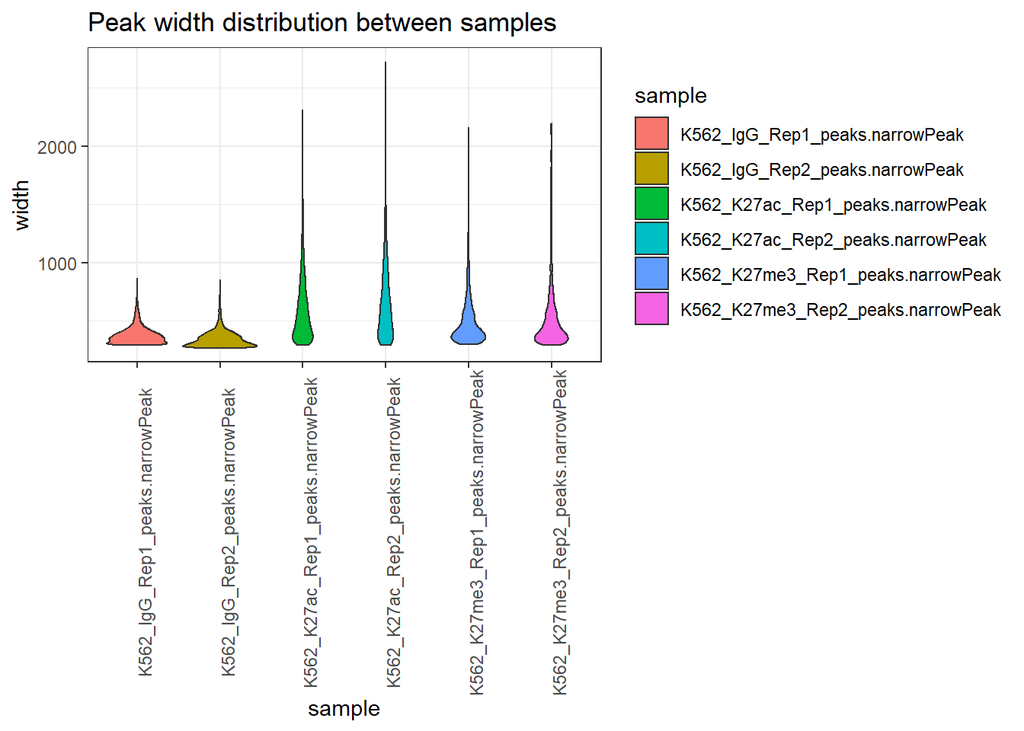

```r
#load library ggplot2
library("ggplot2")

#extract peak width distribution per sample and store in a new data frame:
peakwidth <- data.frame()

for (i in 1:length(peaks_g)) {
  width <- data.frame(width(peaks_g[[i]]))
  width$sample <- names(peaks_g)[i]
  peakwidth <- rbind(peakwidth,width)
}
colnames(peakwidth) <- c("width","sample")
peakwidth$sample <- as.factor(peakwidth$sample)

#plot peak width distribution for all samples as histogram
ggplot(peakwidth, aes(x=sample, y = width, fill=sample)) +
 geom_violin() +
 scale_color_brewer(palette="Dark2")+
 ggtitle("Peak width distribution between samples")+
 theme_bw()+
 theme(axis.text.x = element_text(angle = 90))
```

### 2. Define a consensus peak set for the respective replicates.

But first I like to look at the peak overlap between replicates using a Venn diagram from the `VennDiagram` package for pair-wise comparison.

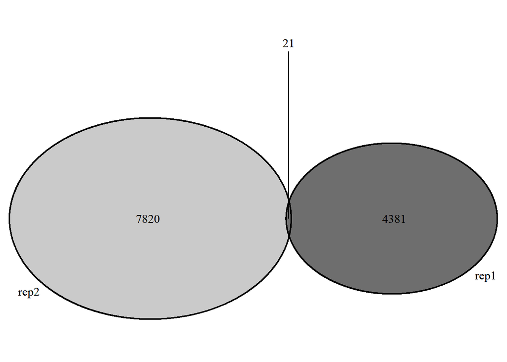

```
## [1] "Venn diagram of IgG samples:"
```

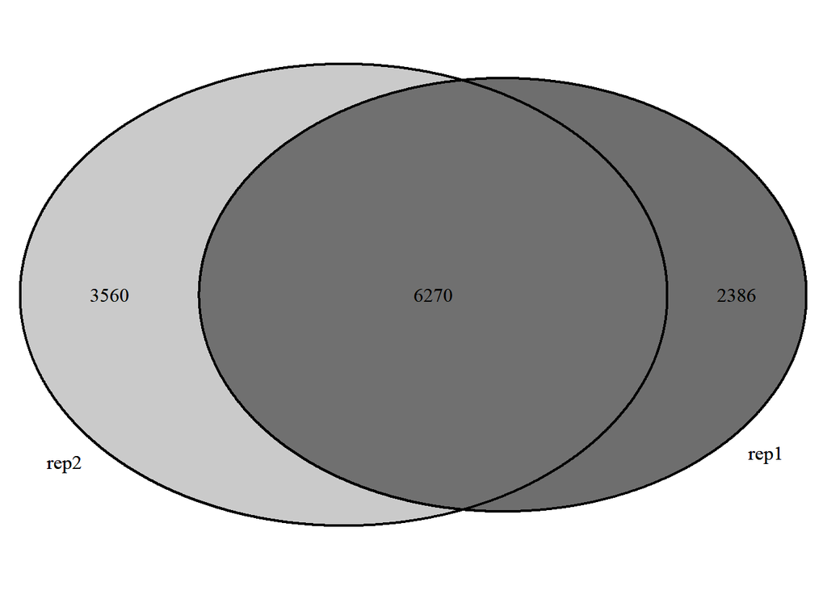

```
## [1] "Venn diagram of K27ac samples:"
```

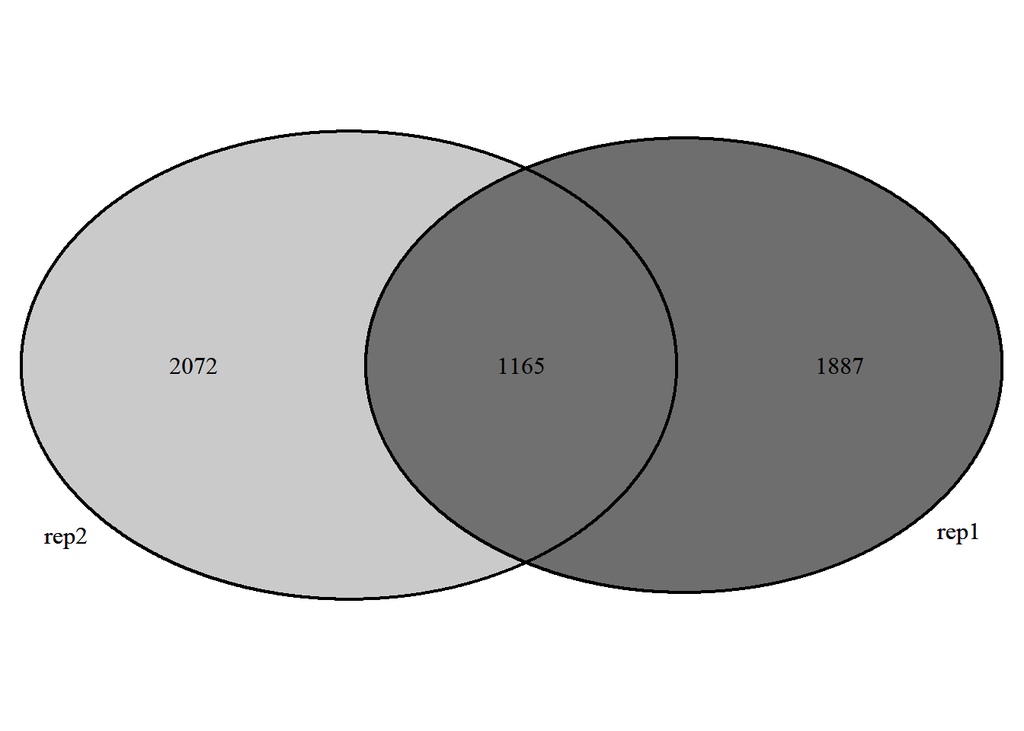

```
## [1] "Venn diagram of K27me3 samples:"
```

```r
#load the VennDiagramm package
library("VennDiagram")

#draw pair-wise proportional Venn diagrams
samples <- seq(1,length(peaks_g),2)
i<-1
for (i in samples) {
  sample <- sub(".*K562_","", names(peaks_g)[i])
  sample <- sub("_.*","", sample)
  print(paste("Venn diagram of",sample,"samples:",sep=" "))
  venn <- draw.pairwise.venn(area1 = length(peaks_g[[i]]), area2 = length(peaks_g[[i+1]]), cross.area = length(subsetByOverlaps(granges(peaks_g[[i]]), granges(peaks_g[[i+1]]), minoverlap = 10,ignore.strand=TRUE)), category = c("rep1","rep2"), euler.d = TRUE, scaled = TRUE, fill = c("grey24","grey72"))
  grid.draw(venn)
  grid.newpage()
}
```

Now, we compute the consensus peak set for each antibody. We also save a BED file of the consensus set for motif enrichment or further analysis.  
**Note**: In case you work with data from transcription factors setting the peak width of 100 bp around the peak summit will improve motif analysis.

```r
#Consensus type 1: e.g. for motifs
i<-1
for (i in samples) {
  sample <- sub(".*K562_","", names(peaks_g)[i])
  sample <- sub("_.*","", sample)
  overlap <- intersect(peaks_g[[i]], peaks_g[[i+1]],ignore.strand=TRUE)
  if (length(overlap)>0){
    overlap <- overlap
  }
  else{overlap <- GRanges()}
  assign(sample,overlap)
  write.table(as.data.frame(overlap)[,c(1:3)],paste("./results/consensusPeaks/K562",sample,"consensusPeaksType1.bed",sep="_"),sep="\t",row.names = FALSE,col.names = FALSE)
  i <- i+2
}
consensus1 <- GRangesList(IgG,K27ac,K27me3)
names(consensus1) <- c("IgG","H3K27ac","H3K27me3")

#Show the number of consensus peaks
for (i in 1:length(consensus1)) {
  print(paste(names(consensus1)[i],length(granges(consensus1[[i]])),sep=": "))
}
```

```
## [1] "IgG: 21"
## [1] "H3K27ac: 6307"
## [1] "H3K27me3: 1177"
```

```r
#library("SparseSummarizedExperiment")

#Consensus type 2: e.g. for quantification
i<-1
for (i in samples) {
  sample <- sub(".*K562_","", names(peaks_g)[i])
  sample <- sub("_.*","", sample)
  overlap <- reduce(append(subsetByOverlaps(peaks_g[[i]], peaks_g[[i+1]],ignore.strand=TRUE,minoverlap=10),subsetByOverlaps(peaks_g[[i+1]], peaks_g[[i]],ignore.strand=TRUE,minoverlap=10)))
  if (length(overlap)>0){
    overlap <- overlap
  }
  else{overlap <- GRanges()}
  assign(sample,overlap)
  write.table(as.data.frame(overlap)[,c(1:3)],paste("./results/consensusPeaks/K562",sample,"consensusPeaksType2.bed",sep="_"),sep="\t",row.names = FALSE,col.names = FALSE)
  i <- i+2
}
consensus2 <- GRangesList(IgG,K27ac,K27me3)
names(consensus2) <- c("IgG","H3K27ac","H3K27me3")

#Show the number of consensus peaks
for (i in 1:length(consensus2)) {
  print(paste(names(consensus2)[i],length(granges(consensus2[[i]])),sep=": "))
}
```

```
## [1] "IgG: 21"
## [1] "H3K27ac: 6218"
## [1] "H3K27me3: 1158"
```

#### Irreproducible Discovery Rate (IDR)

The aim of IDR is to define reproducibly-called regions by quantitatively defining peak regions that are no longer reproducible among replicates (irreproducible). The p-value from peak calling is used as quality criterion (obtained as score in the _peaks.narrowPeak files) to rank peaks and classifies the signal into reproducible and irreproducible using a copula mixture model (see Li et al. arXiv 2011 (https://arxiv.org/abs/1110.4705) for more details).  
As peaks are evaluated on the basis of scores, only peaks called in both replicates are considered in IDR analysis. Therefor, IDR analysis is performed on low stringent peak calls (e.g. MACS peak calls with P<1e-5, FDR=0.1 or unfiltered).  
The `idr` package for R needs to be downloaded from CRAN (https://cran.r-project.org/web/packages/idr/index.html) and installed from source using the `install.package()` function.

```r
library("idr")
#look at consensus peaks
samples <- seq(1,length(peaks_g),2)
i<-1
for (i in samples) {
  sample <- sub(".*K562_","", names(peaks_g)[i])
  sample <- sub("_.*","", sample)
  fo <- as.data.frame(findOverlaps(peaks_g[[i]], peaks_g[[i+1]],ignore.strand=TRUE,minoverlap=10))
  fo <- fo[!duplicated(fo$queryHits) & !duplicated(fo$subjectHits),]
  overlap <- as.data.frame(peaks_g[[i]][fo[,1]])
  overlap <- cbind(overlap,peaks_g[[i]]$pvalue[fo[,1]], peaks_g[[i+1]]$pvalue[fo[,2]])
  res <- est.IDR(overlap[,c(8:9)], mu=3, sigma=1, rho=.9, p=.5)
  overlap <- cbind(overlap,idr=res$idr) #local idr
  colnames(overlap) <- c("seqnames","start","end","width","strand","score","pvalue","score_rep1","score_rep2","idr")
  print(paste("Signal reproducibility among",sample,"replicates:",sep=" "))
  ggplot(overlap, aes(score_rep1,score_rep2,col=idr)) + geom_point()
  if (nrow(overlap[overlap$idr<0.05 &overlap$idr!=0 ,])>0){
    idr <- bed2GRanges(overlap[overlap$idr<0.05 &overlap$idr!=0 ,c(1:3,5,6,4,8,7)])
  }
  else{idr <- GRanges()}
  assign(sample,idr)
  write.table(as.data.frame(idr)[,c(1:3)],paste("./results/consensusPeaks/K562",sample,"IDR005.bed",sep="_"),sep="\t",row.names = FALSE,col.names = FALSE)
  i <- i+2
}
```

```
## [1] "Signal reproducibility among IgG replicates:"
## [1] "Signal reproducibility among K27ac replicates:"
## [1] "Signal reproducibility among K27me3 replicates:"
```

```r
idr_peaks<- GRangesList(IgG,K27ac,K27me3)
names(idr_peaks) <- c("IgG","H3K27ac","H3K27me3")

#Show the number of consensus peaks
for (i in 1:length(idr_peaks)) {
  print(paste(names(idr_peaks)[i],length(granges(idr_peaks[[i]])),sep=": "))
}
```

```
## [1] "IgG: 0"
## [1] "H3K27ac: 1963"
## [1] "H3K27me3: 842"
```

The main drawback of IDR analysis is its limitation towards pair-wise comparison. In cases of more than two replicates, commonly unions of pair-wise reproducible peaks are used to define the consensus peak set. Defining peaks based on consensus peak sets (e.g. overlaps or IDR) can be unreliable especially if one replicate is of lower quality. One approach is to increase the number of replicates and define a) a high confidence peak set by filtering for peak regions only recovered in all replicates (good and bad), b) a likely consensus peak set as union of pair-wise reproducible peaks or c) defining a possible peak space by looking at the union of peaks from all replicates. The choice of consensus peak set will depend on the downstream analysis and the purpose of the experiment.  
A second drawback of peak overlaps is the definition of peak boundaries. Peak boundaries/width depend on the resolution of the assay used as well as on the quality of the data. Boundaries reported from peak callers like MACS are fuzzy.  
Again, we can use the consensus peak type 1 approach to define the peak boundaries very stringently by only including regions recovered in all replicates. Another elegant approach is ChIP-R and was described by Newell et al. in Genomics 2021 (https://doi. org/10.1016/j.ygeno.2021.04.026). ChIP-R classifies canonical fragments from k replicates on there recovery in i€k replicates based on coordinates. Afterwards each of the canonical fragments is assigned a rank based on their respective signal (from the peak caller, can be pile-up or p-value) per replicate. Each rank tuple is evaluated by the rank product test and peak boundaries are defined by merging fragments passing a user defined significance threshold. However, this tool is not yet implemented in R.  
#### Look at more then two sample overlaps  
a.) Three sample Venn diagram  
Pair-wise Venn diagrams are ideal to represent peak overlaps in a proportional way. So called Euler diagrams can also visualize more then 2 peak sets by fitting a model that approximates the best proportional representation. The more peak sets the less accurate will a 2-dimensional representation with regards to proportionality of areas be. Therefor, I do not recommend using Venn diagrams with more then 3 data sets.  
We are using the `eulerr` package (Micallef et al. PLOS ONE 2014, https://doi.org/10.1371/journal.pone.0101717.). Refer to https://cran.r-project.org/web/packages/eulerr/vignettes/introduction.html for the documentation.

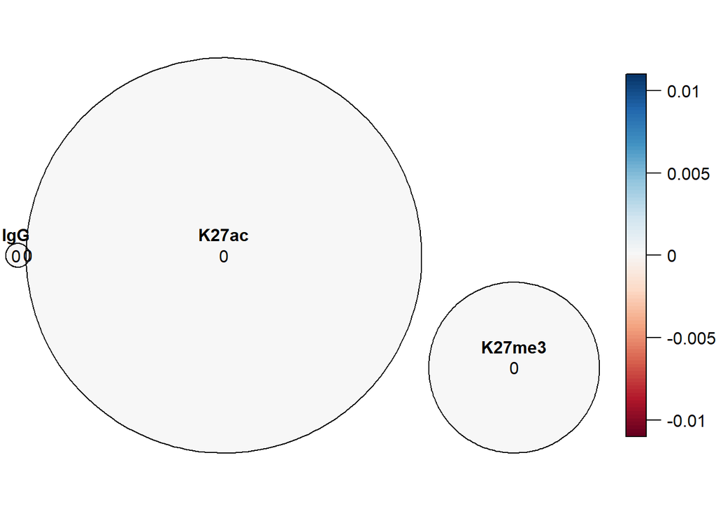

```r
#load the eulerr package
library("eulerr")

#estimate set sizes from the consensus type 1 set
setIgg <- length(consensus1[[1]])
setK27ac <- length(consensus1[[2]])
setK27me3 <- length(consensus1[[3]])
setIgGK27ac <- length(findOverlaps(consensus1[[1]], consensus1[[2]], ignore.strand = TRUE, minoverlap = 10))
setIgGK27me3 <- length(findOverlaps(consensus1[[1]], consensus1[[3]], ignore.strand = TRUE, minoverlap = 10))
setK27acK27me3 <- length(findOverlaps(consensus1[[2]], consensus1[[3]], ignore.strand = TRUE, minoverlap = 10))
all <- length(findOverlaps(GenomicRanges::intersect(consensus1[[1]], consensus1[[2]]),GenomicRanges::intersect(consensus1[[1]], consensus1[[3]])))
#fit the representation model using the euler function
fit <- euler(c("IgG" = setIgg, "K27ac" = setK27ac, "K27me3" = setK27me3, "IgG&K27ac" = setIgGK27ac, "IgG&K27me3" = setIgGK27me3, "K27ac&K27me3" = setK27acK27me3, "IgG&K27ac&K27me3" = all))
#You can look at the goodness of the fit using the error_plot() function
error_plot(fit)
```

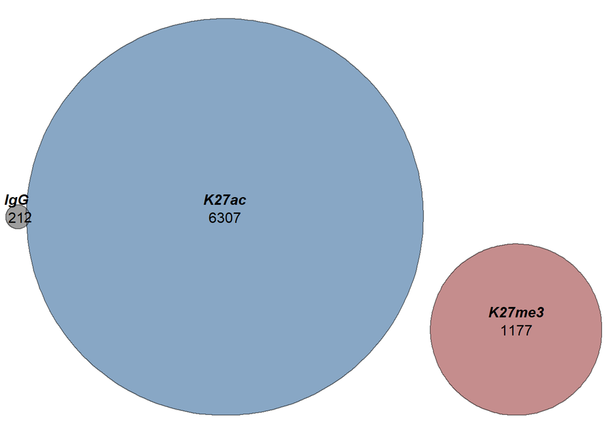

```r
#plot the actual Venn Diagram
plot(fit, quantities=TRUE, fill = c("grey24","dodgerblue4","firebrick4"),labels = list(font=4), alpha=.5)
```

The 3 antibodies used for Cut&Tag occupy mostly non-overlapping genomic regions, with IgG (negative control) having the fewest consensus peaks.  
b.) UpsetR plots for more complex comparisons.  
For more complex comparisons, we are using the `UpsetR` package (Conway, Lex and Gehlenborg Bioinformatics 2017; https://doi.org/10.1093/bioinformatics/btx364). Find an extended documentation here: https://jokergoo.github.io/ComplexHeatmap-reference/book/upset-plot.html.\ We will compare our 3 data sets at this point but come back to `UpsetR` plots later when looking at overlaps with genomic features. The `upset` function from `UpSetR` uses an interaction matrix as input in which 0 represents no peak overlap and 1 a peak overlap in a pair-wise comparison.

```r
#load the UpsetR package
library("UpSetR")

#first generate an interaction matrix
#generate a Grange object with the universe of all peaks
universe <- append(consensus1[[1]],consensus1[[2]])
universe <- append(universe, consensus1[[3]])
names(universe) <- paste(seqnames(universe),start(universe),end(universe),sep="_")
#sanity check
length(universe)==length(consensus1[[1]])+length(consensus1[[2]])+length(consensus1[[3]])
```

```
## [1] TRUE
```

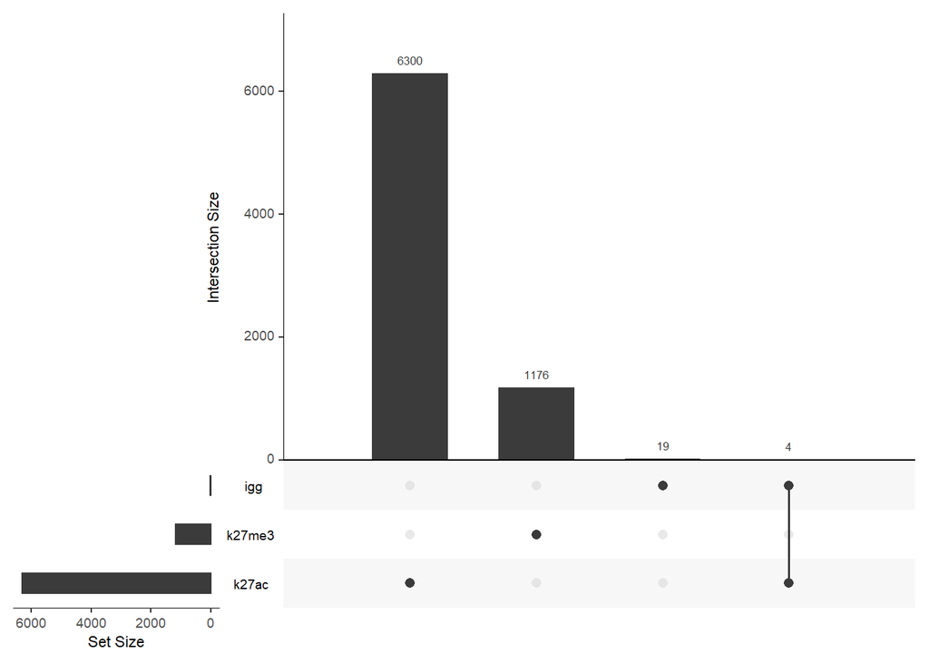

```r
#compute the interaction matrix
matrix <- data.frame(universe)
matrix$ID <- paste(matrix$seqnames,matrix$start,matrix$end,sep="_")
matrix$igg <- ifelse(matrix$ID%in%names(subsetByOverlaps(universe,consensus1[[1]],ignore.strand=TRUE,minoverlap=10)),1,0)
matrix$k27ac <- ifelse(matrix$ID%in%names(subsetByOverlaps(universe,consensus1[[2]],ignore.strand=TRUE,minoverlap=10)),1,0)
matrix$k27me3 <- ifelse(matrix$ID%in%names(subsetByOverlaps(universe,consensus1[[3]],ignore.strand=TRUE,minoverlap=10)),1,0)

#plot interactions
upset(matrix) #by default sets are ordered by size
```

By default, sets are ordered by size. You can change several parameters like ordering sets by degree of interaction instead of frequency using the `order.by` argument. If you have many sets,you can limit the number sets with the `sets` arguments or the number of intersects to show with `nintersects`. The top n sets or intersects will be shown depending on your ordering parameters. The set bar color can be modified using `sets.bar.color` and the main bar color with `main.bar.color`. This will also affect the color of the set size text. Point sizes can be adjusted using `point.size`, line thickness with `line.size` and axis labels added using `mainbar.y.label` and `sets.x.label`. The different text layers of the plot can be modified with the `text.scale` argument that takes a vector with `c(intersection size title, intersection size tick labels, set size title, set size tick labels, set names, numbers above bars)`.

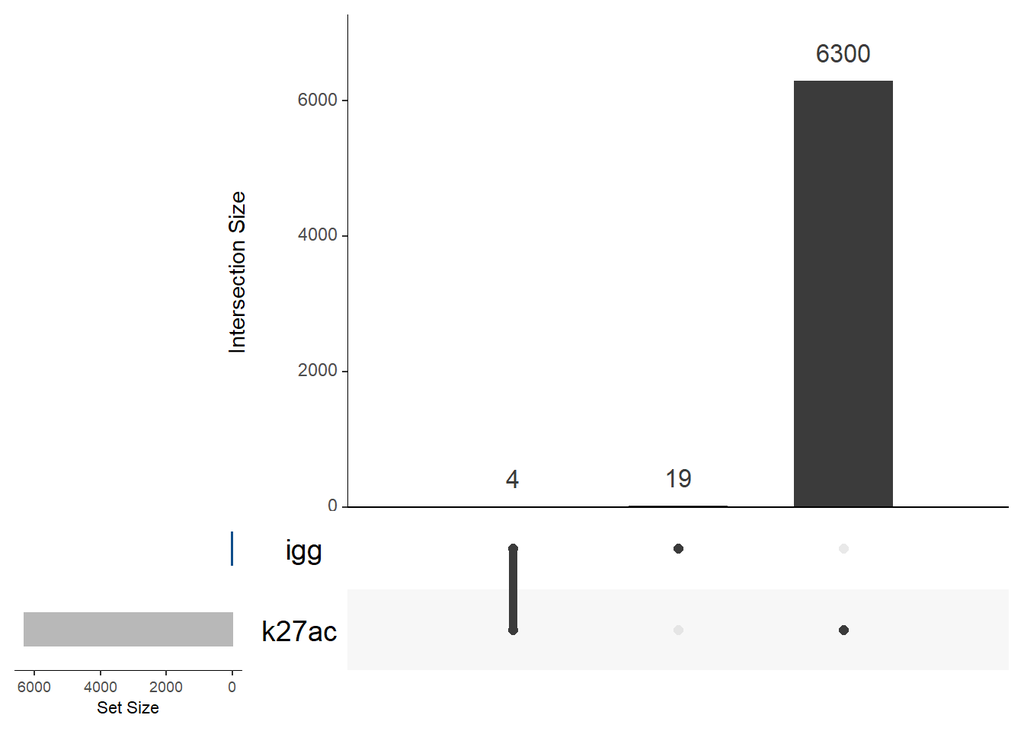

```r
upset(matrix, order.by = "degree", sets=c("k27ac", "igg"), sets.bar.color=c("grey72","dodgerblue4"),point.size =2, line.size=2, text.scale = c(1.3, 1.3, 1, 1, 2, 2))
```

You can also group interactions by sets using `group.by`. You can set the cutoff for displayed interactions per set using the `cutoff` argument. If you want to display empty intersects set `, empty.intersections = "on"`.

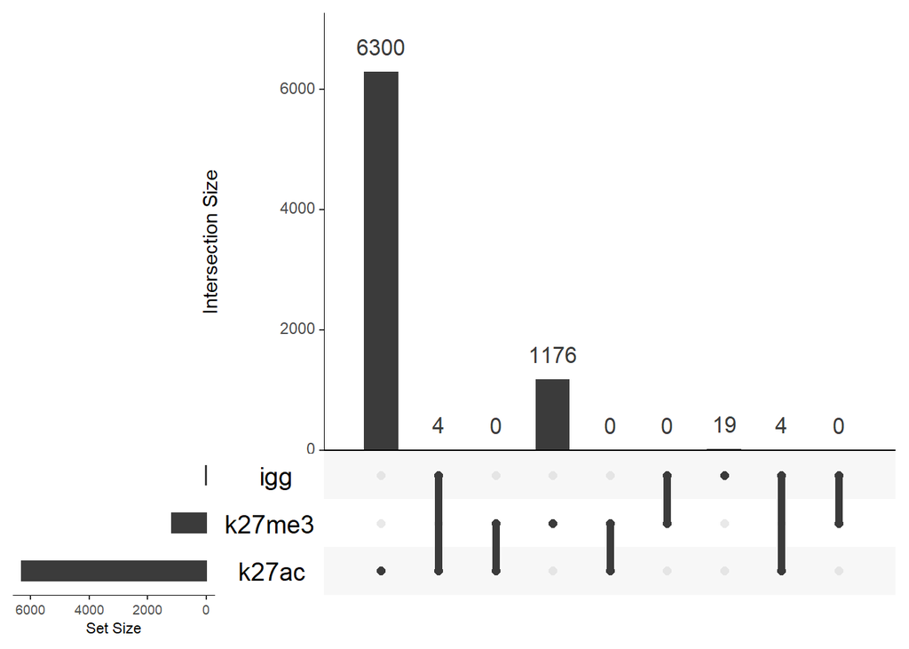

```r
upset(matrix, order.by = "freq", nintersects=20, group.by="sets", cutoff=3, point.size =2, line.size=2,text.scale = c(1.3, 1.3, 1, 1, 2, 2), empty.intersections = "on")
```

Just looking at the number of overlapping genes ignores the size of the peak sets and may therefor be biased. Hence, we normalize the peak overlap by the peak union size to generate an index reflecting the proportional peak set overlap (Jaccard index). As the consensus peak sets of our example data has very few overlapping peaks, we use the replicates to compute a matrix of Jaccard indices. Fur this purpose, we generate a function called `jaccard` that computes the jaccard index for two peak sets.

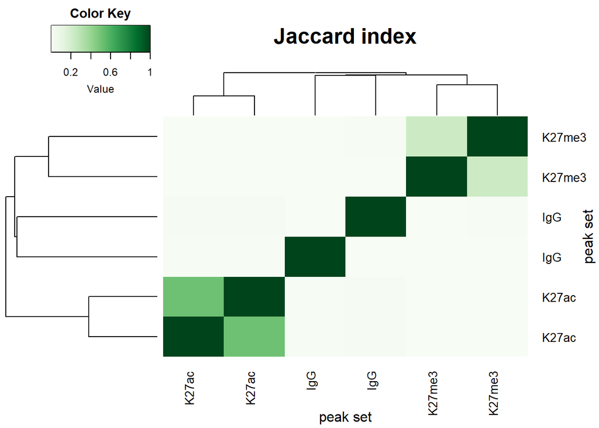

```r
#define a function computing the Jaccard index
jaccard <- function(set1, set2){
  intersect <- GenomicRanges::intersect(set1, set2)
  union <- append(GenomicRanges::intersect(set1, set2), subsetByOverlaps(set1, set2,invert=TRUE,ignore.strand=TRUE, minoverlap=10))
  union <- append(union,subsetByOverlaps(set2, set1,invert=TRUE,ignore.strand=TRUE, minoverlap=10))
  jaccard <- length(intersect)/length(union)
  return(jaccard)
}

#compute the Jaccard indices for all samples in peaks_g and store as matrix jaccarM
jaccardM <- endoapply(peaks_g ,function(x){endoapply(peaks_g, function(y){jaccard(x,y)})})
jaccardM <- matrix(unlist(do.call("cbind",jaccardM)),ncol=length(peaks_g))
colnames(jaccardM) <- c(sub("_.*","",sub(".*K562_","",names(peaks_g)[seq(names(peaks_g))])))
rownames(jaccardM) <- c(sub("_.*","",sub(".*K562_","",names(peaks_g)[seq(names(peaks_g))])))

#plot jaccard index as heatmap
#load packaes required for plotting
library("gplots")
library("RColorBrewer")
#define color scale for heatmap
col <- colorRampPalette(brewer.pal(10, "Greens"))(256)
#heatmap of jaccard indices
heatmap.2(jaccardM,
          scale = "none",
          col = col,
          trace = "none",
          density.info = "none",
          xlab = "peak set",
          ylab ="peak set",
          cexRow=1,
          cexCol=1,
          main="Jaccard index")
```

You see a high overlap between the H3K27ac replicates and H3K27me3 to a lesser extend (indicated by the color saturation), but no overlap between H3K27ac, H3K27me3 and IgG as previously also observed in the Venn diagram.

### 3. Annotate peak positions to the closest gene.

For simplicity and due to our limited understanding of gene regulation, peaks are usually associated to the overlapping or closest gene in the linear genome. In case of expression data being available, you could limit the search space by filtering for expressed genes within a given tissue/cell type. More advanced algorithms using different data sources are GREAT (http://great.stanford.edu/great/public/html/), BETA (http://cistrome.org/BETA/) or multiple peak-to-gene and gene-to-peak associations like FindIT2 (https://bioconductor.org/packages/devel/bioc/vignettes/FindIT2/inst/doc/FindIT2.html).  
Here we will use the `annotatePeak` function from the `ChIPpeakAnno` package to annotate our peaks to the closest transcriptional start site (TSS). For more details on the `ChIPpeakAnno` package refer to the vignette https://bioconductor.org/packages/devel/bioc/vignettes/ChIPseeker/inst/doc/ChIPseeker.html.\  
#### A) We need to define an annotation object.  
Annotation data for each genome can be retrieved within R using the Bioconductor package `AnnotationHub`. Find useful information in the vignette (https://bioconductor.org/packages/release/bioc/html/AnnotationHub.html). `AnnotationHub` is a Web resource of genomic files. This resource is constantly changing. Therefor, we will grab a snap shot of annotation hub, that is locally stored and can be used to maintain reproducibility.

```r
#laod libraries AnnotationHub and ChIPseeker
library("AnnotationHub")
library("ChIPpeakAnno")
library("GenomicFeatures")

#create an AnnotationHub instance
ah <- AnnotationHub()

#find the indexes to access the data
#ah[1]

#first we select the species of interest (e.g. Homo sapiens)
subset(ah, species == "Homo sapiens")
```

```
## AnnotationHub with 26509 records
## # snapshotDate(): 2022-04-25
## # $dataprovider: BroadInstitute, UCSC, Ensembl, GENCODE, UWashington, Stanfo...
## # $species: Homo sapiens
## # $rdataclass: GRanges, BigWigFile, Rle, ChainFile, TwoBitFile, list, data.f...
## # additional mcols(): taxonomyid, genome, description,
## #   coordinate_1_based, maintainer, rdatadateadded, preparerclass, tags,
## #   rdatapath, sourceurl, sourcetype
## # retrieve records with, e.g., 'object[["AH5012"]]'
##
##              title
##   AH5012   | Chromosome Band
##   AH5013   | STS Markers
##   AH5014   | FISH Clones
##   AH5015   | Recomb Rate
##   AH5016   | ENCODE Pilot
##   ...        ...
##   AH100418 | TxDb.Hsapiens.UCSC.hg38.knownGene.sqlite
##   AH100419 | TxDb.Hsapiens.UCSC.hg38.refGene.sqlite
##   AH100480 | LRBaseDb for Homo sapiens (Human, v003)
##   AH100643 | Ensembl 106 EnsDb for Homo sapiens
##   AH104864 | Ensembl 107 EnsDb for Homo sapiens
```

```r
#You can use the query() function to look for specific resources
#query(ah, "hg19")
#or the browser
#display(ah)

#after looking for gene information on Homo sapiens genome build hg19/GRCh37, we identified the following options
#a) ENSEMBL GRCh37 release 75: AH10684 (date: 2014-04-27)
#b) GENCODE GRCh37: AH75128 (date: 2019-10-08)
#c) UCSC Ref-Seq genes for hg19: AH5040 (date: 2013-03-26)
#d) UCSC known genes for hg19: AH5036 (date: 2013-3-26)
#We will use the most recent one from Gencode
txdb1 <- as.data.frame(ah[["AH75128"]])
#filter for unique genes
txdb1 <- txdb1[txdb1$type=="transcript",]
#remvoe version info on geneIDs
txdb1$gene_id <- sub("\\..*", "", txdb1$gene_id)
txdb1 <- txdb1[!duplicated(txdb1$gene_id),]
annoData <- GRanges(seqnames=txdb1[,1],range=IRanges(start=txdb1[,2], end=txdb1[,3], names=txdb1[,11]), strand=txdb1[,5])


for (i in 1:length(consensus1)) {
  anno <- annotatePeakInBatch(consensus1[[i]], AnnotationData=annoData, output="shortestDistance", featureType = "TSS",PeakLocForDistance = "middle",select = "first")
  assign(names(consensus1[i]),anno)
  write.table(as.data.frame(anno),paste("./results/consensusPeaks/K562",sample,"consensusPeaksType1_annotated.txt",sep="_"),sep="\t",row.names = FALSE,col.names = TRUE)
}
annoPeaks <- GRangesList("IgG" = IgG,"H3K27ac" = H3K27ac,"H3K27me3" = H3K27me3)
```

Alternatives to AnnotationHub are build-in annotation databases in R provided by UCSC (!Ref-Seq gene annotation) or ENSEMBL. Alternatively, you can use your own GFF3/GTF files as gene annotation. Finally, we make use of the `UpSetR` package to see that if the annotations differ dependent on the gene annotation source.

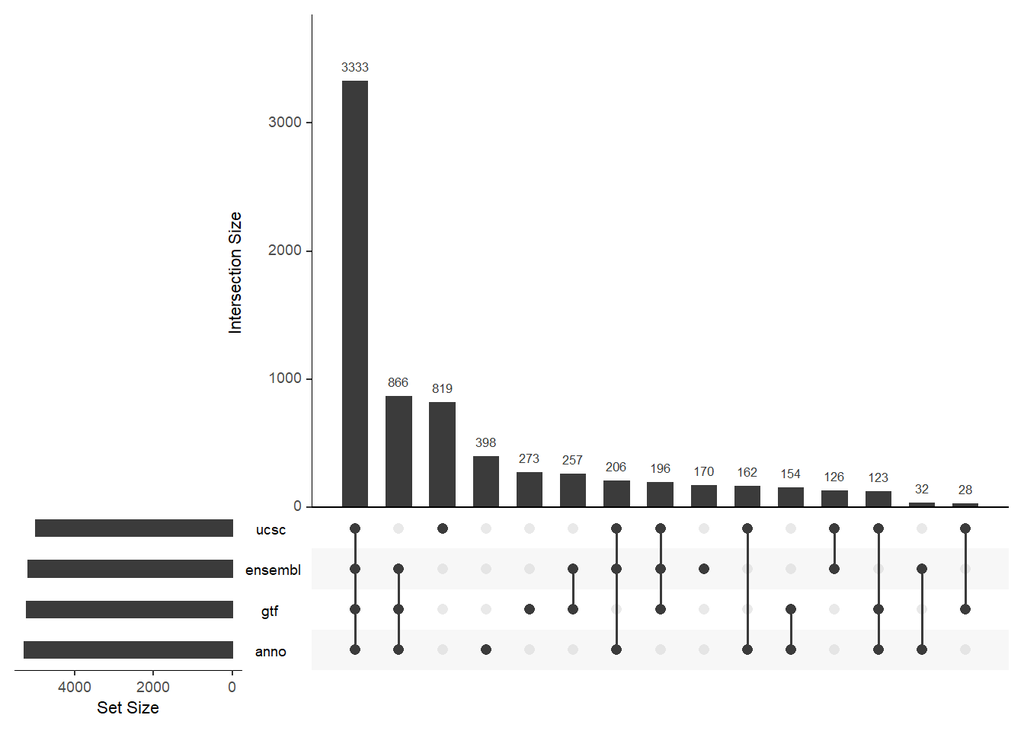

```r
library("TxDb.Hsapiens.UCSC.hg19.knownGene")
library("EnsDb.Hsapiens.v75")
library("tidyr")
#load UCSC genes
annoData2 <- genes(TxDb.Hsapiens.UCSC.hg19.knownGene)

#annotated using build-in UCSC known genes
for (i in 1:length(consensus1)) {
  anno <- annotatePeakInBatch(consensus1[[i]], AnnotationData=annoData2, output="shortestDistance", featureType = "TSS",PeakLocForDistance = "middle",select = "first")
  #convert UCSC gene IDs into ENSEMBL
  anno <- addGeneIDs(annotatedPeak=anno, orgAnn="org.Hs.eg.db", feature_id_type="entrez_id",IDs2Add="ensembl")
  assign(names(consensus1[i]),anno)
}
annoPeaks_UCSC <- GRangesList("IgG" = IgG,"H3K27ac" = H3K27ac,"H3K27me3" = H3K27me3)

#load ENSEMBL transcripts
annoData3 <- toGRanges(EnsDb.Hsapiens.v75, feature="gene")
#annotated using build in ENSEMBL genes
for (i in 1:length(consensus1)) {
  anno <- annotatePeakInBatch(consensus1[[i]], AnnotationData=annoData3, output="shortestDistance", featureType = "TSS",PeakLocForDistance = "middle",select = "first")
  assign(names(consensus1[i]),anno)
}
annoPeaks_ensembl <- GRangesList("IgG" = IgG,"H3K27ac" = H3K27ac,"H3K27me3" = H3K27me3)

#load own GTF file
gtf <- read.table("./data/gencode.v19.annotation.gtf",header=FALSE,sep="\t",stringsAsFactors = FALSE)
colnames(gtf) <- c("chr","source","type","start","end","score","strand","phase","info")
#filter for transcripts
gtf <- gtf[gtf$type=="transcript",]

#retrieve the meta information stored in info
gtf$gene_id<-gsub(x = gtf$info,pattern = ".*gene_id ",replacement = "")
gtf$gene_id<-gsub(x = gtf$gene_id,pattern = "\\;.*",replacement = "")
gtf$transcript_id<-gsub(x = gtf$info,pattern = ".*transcript_id ",replacement = "")
gtf$transcript_id<-gsub(x = gtf$transcript_id,pattern = "\\;.*",replacement = "")
gtf$gene_name<-gsub(x = gtf$info,pattern = ".*gene_name ",replacement = "")
gtf$gene_name<-gsub(x = gtf$gene_name,pattern = "\\;.*",replacement = "")
gtf$gene_name<-ifelse(grepl(x=gtf$gene_name,pattern ="transcript_id"),"NA",gtf$gene_name)

#remvoe version info on geneIDs
gtf$gene_id <- sub("\\..*", "", gtf$gene_id)
gtf <- gtf[!duplicated(gtf$gene_id),]
annoData4 <- GRanges(seqnames=gtf[,1],range=IRanges(start=gtf[,4], end=gtf[,5], names=gtf[,10]), strand=gtf[,7])
#annotate
for (i in 1:length(consensus1)) {
  anno <- annotatePeakInBatch(consensus1[[i]], AnnotationData=annoData4, output="shortestDistance", featureType = "TSS",PeakLocForDistance = "middle",select = "first")
  assign(names(consensus1[i]),anno)
}
annoPeaks_gtf <- GRangesList("IgG" = IgG,"H3K27ac" = H3K27ac,"H3K27me3" = H3K27me3)

#compare associated genes in H3K27ac data for all 3 annotation objects
ucsc1 <- sub(";.*", "",as.data.frame(annoPeaks_UCSC[[2]])$ensembl)
ucsc2 <- sub(".*;", "",as.data.frame(annoPeaks_UCSC[[2]])$ensembl)
ucsc <- unique(c(ucsc1,ucsc2))

features <- unique(c(as.data.frame(annoPeaks[[2]])$feature,ucsc,as.data.frame(annoPeaks_ensembl[[2]])$feature,as.data.frame(annoPeaks_gtf[[2]])$feature))
features <- as.data.frame(features)
colnames(features) <- "features"

features$anno <- ifelse(features$features%in%as.data.frame(annoPeaks[[2]])$feature,1,0)
features$ucsc <- ifelse(features$features%in%ucsc,1,0)
features$ensembl <- ifelse(features$features%in%as.data.frame(annoPeaks_ensembl[[2]])$feature,1,0)
features$gtf <- ifelse(features$features%in%as.data.frame(annoPeaks_gtf[[2]])$feature,1,0)

upset(features,nintersects=20,order.by = "freq")
```

Once the peaks are annotated, the distribution of the distance to the nearest feature such as the transcription start sites (TSS) can be plotted. The sample code here plots the distribution of the aggregated peak scores and the number of peaks around the TSS of the H3K27ac data. We define a score parameter that aggregates the number of peaks at close to the TSS.

```r
k27ac_anno <- annoPeaks[[2]]
k27ac_anno$score <- 1
binOverFeature(annoPeaks[[2]], k27ac_anno, annotationData=annoData,radius=5000, nbins=10, FUN=c(sum, length), ylab=c("score", "count"),     main=c("Distribution of aggregated peak scores around TSS", "Distribution of aggregated peak numbers around TSS"))
```

```
## score of GRanges object is required for calculation.
##                     It will be the input of FUN. Setting score as 1.
```

[figure not shown]

We can also plot the distribution of peaks overlapping genomic features.

```r
#We need a txdb object resembling the annotation we used
txdb1 <- makeTxDbFromGRanges(ah[["AH75128"]])
```

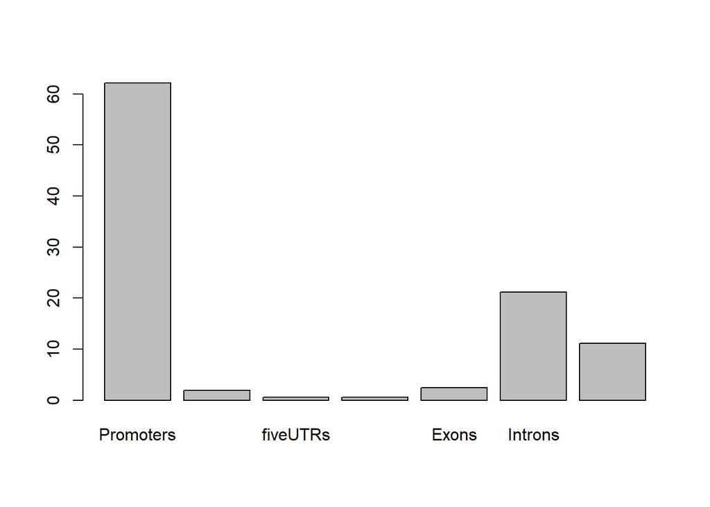

```r
genomicDistribution<-assignChromosomeRegion(annoPeaks[[2]], nucleotideLevel=FALSE,precedence=c("Promoters", "immediateDownstream","fiveUTRs", "threeUTRs","Exons", "Introns"),TxDb=txdb1)
#plot the percentage of the overlap as barplot
barplot(genomicDistribution$percentage)
```

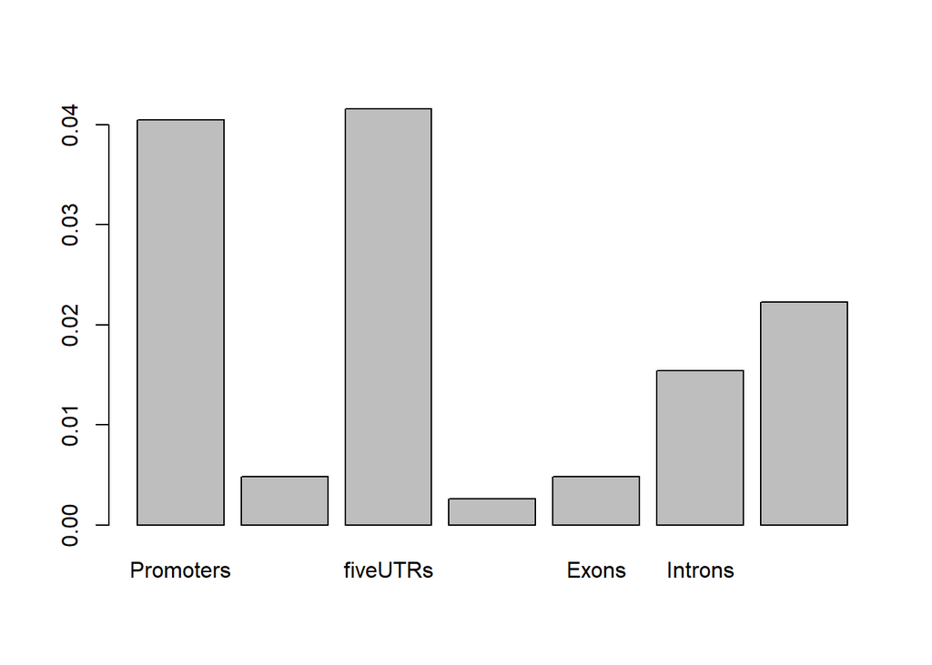

```r
#plot the jaccard index of the overlap as barplot
barplot(genomicDistribution$jaccard)
```

A second popular annotation package in R is `ChIPseeker`. We can use the `anntotatePeak` function, which only works with Txdb objects. Therefore, we have to convert all different annotation sources into Txdb objects first.

```r
library("ChIPseeker")
#from annotation hub
txdb1 <- makeTxDbFromGRanges(ah[["AH75128"]])
#We can use lapply instead of for loops to annotate all 3 GRanges objects in our list
annoPeaks_CS <- lapply(consensus1, annotatePeak, TxDb=txdb1,tssRegion=c(-1000, 500),level = "gene",annoDb = "org.Hs.eg.db", verbose=FALSE)

#annotated using build-in UCSC known genes
txdb2 <- TxDb.Hsapiens.UCSC.hg19.knownGene
annoPeaks_CS_UCSC <- lapply(consensus1, annotatePeak, TxDb=txdb2,tssRegion=c(-1000, 500),level = "gene",annoDb = "org.Hs.eg.db", verbose=FALSE)

#load ENSEMBL transcripts
seqlevelsStyle(EnsDb.Hsapiens.v75) <- "UCSC"
annoPeaks_CS_ensembl <- lapply(consensus1, annotatePeak, TxDb=EnsDb.Hsapiens.v75,tssRegion=c(-1000, 500),level = "gene",annoDb = "org.Hs.eg.db", verbose=FALSE)
```

[output not shown]

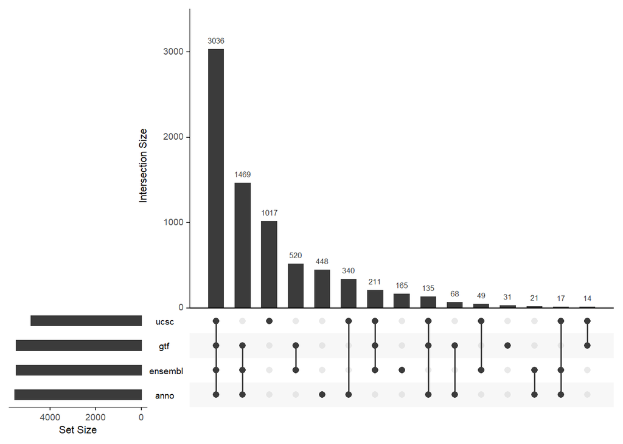

```r
#annotate using GTF file
#convert GTF into Txdb object using makeTxDbFromGFF from the GenomicFeatures package
txdb4 <- makeTxDbFromGFF("./data/gencode.v19.annotation.gtf",format = "gtf",dataSource = "GENCODE",organism = "Homo sapiens")
annoPeaks_CS_gtf <- lapply(consensus1, annotatePeak, TxDb=txdb4,tssRegion=c(-1000, 500),level = "gene",annoDb = "org.Hs.eg.db", verbose=FALSE)

#compare associated genes in H3K27ac data for all 3 annotation objects
#note that gtf gene ids will still have the gene version info
features <- unique(c(sub("\\..*", "",as.data.frame(annoPeaks_CS[[2]])$geneId),as.data.frame(annoPeaks_CS_UCSC[[2]])$ENSEMBL,as.data.frame(annoPeaks_CS_ensembl[[2]])$geneId,sub("\\..*", "", as.data.frame(annoPeaks_CS_gtf[[2]])$geneId)))
features <- as.data.frame(features[!is.na(features)])
colnames(features) <- "features"

features$anno <- ifelse(features$features%in%sub("\\..*", "",as.data.frame(annoPeaks_CS[[2]])$geneId),1,0)
features$ucsc <- ifelse(features$features%in%as.data.frame(annoPeaks_CS_UCSC[[2]])$ENSEMBL,1,0)
features$ensembl <- ifelse(features$features%in%as.data.frame(annoPeaks_CS_ensembl[[2]])$geneId,1,0)
features$gtf <- ifelse(features$features%in%sub("\\..*", "", as.data.frame(annoPeaks_CS_gtf[[2]])$geneId),1,0)

upset(features,nintersects=20,order.by = "freq")
```

The `ChIPseeker` package also includes some build-in functions to look at the genomic distribution. See the code below for some examples using the H3K27ac data. Find more information on the `ChIPseeker` in the vignette (https://bioconductor.org/packages/devel/bioc/vignettes/ChIPseeker/inst/doc/ChIPseeker.html#peak-annotation). **Note**: Feel free to modify the code in order to look at H3K27me3.

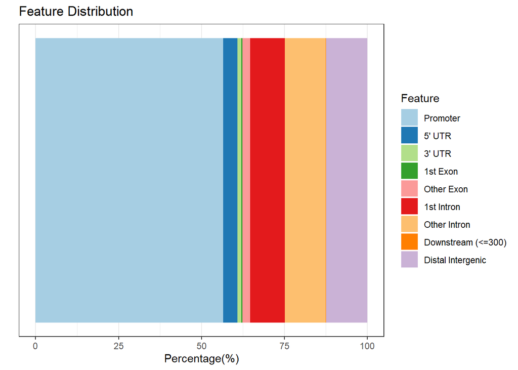

```r
#genomic feature distribution as bar plot
plotAnnoBar(annoPeaks_CS[[2]])
```

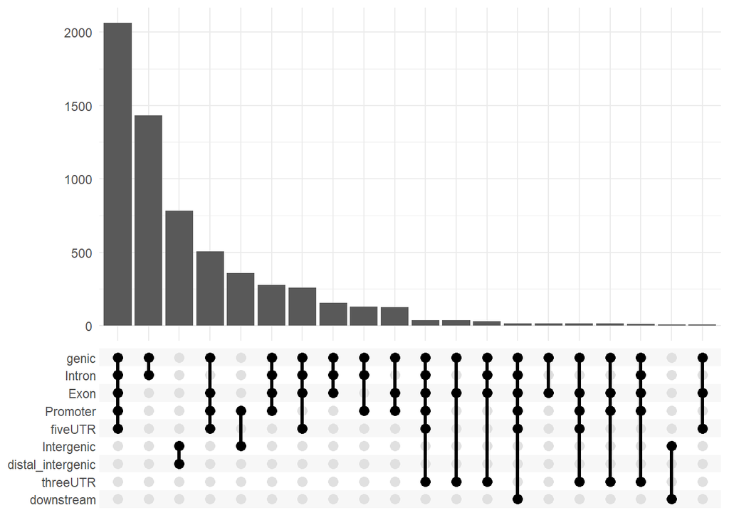

```r
#genomic feature distribution as upset plot looking at combinations of genomic locations per gene
upsetplot(annoPeaks_CS[[2]])
```

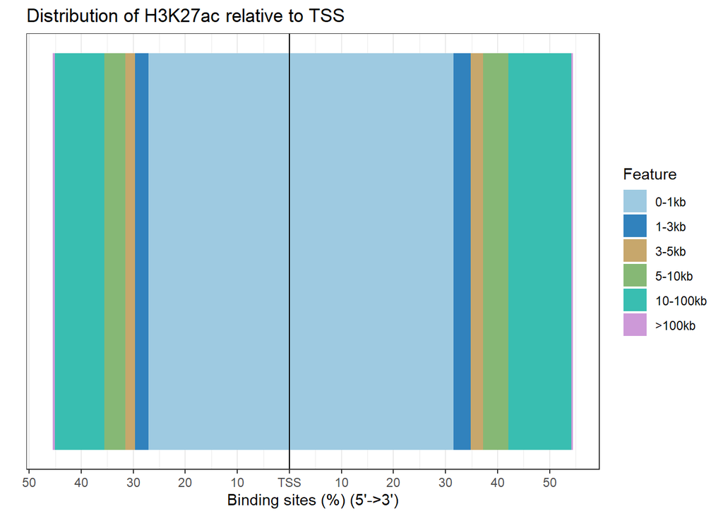

```r
#genomic distance of peaks relative to TSS as bar plot
plotDistToTSS(annoPeaks_CS[[2]], title=paste("Distribution of",names(annoPeaks_CS)[[2]],"relative to TSS",sep=" "))
```

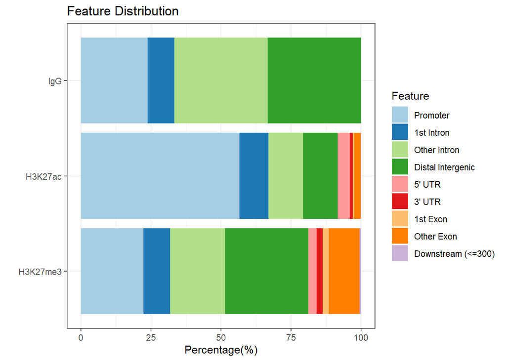

```r
#ChIPseeker can also compare peak sets when provided as list
#genomic feature distribution as bar plot
plotAnnoBar(annoPeaks_CS)
```

Just as side note here. You can retrieve all the annotation information e.g. the peaks overlapping promoters as data frames or `GRange` objects with classical sub-setting. I only show one example here.

```r
k27ac <- as.data.frame(annoPeaks_CS[[2]])
k27ac_prom <- GRanges(k27ac[k27ac$annotation=="Promoter",])
head(k27ac_prom)
```

```
## GRanges object with 6 ranges and 11 metadata columns:
##     seqnames          ranges strand |  annotation   geneChr geneStart   geneEnd
##        <Rle>       <IRanges>  <Rle> | <character> <integer> <integer> <integer>
##   1     chr1   762745-763035      * |    Promoter         1    761586    762902
##   2     chr1   935844-936166      * |    Promoter         1    934342    935552
##   3     chr1   954981-955358      * |    Promoter         1    955500    991498
##   4     chr1 1166986-1167559      * |    Promoter         1   1152288   1167447
##   5     chr1 1209150-1209758      * |    Promoter         1   1189294   1209265
##   8     chr1 1259867-1260386      * |    Promoter         1   1246965   1260071
##     geneLength geneStrand             geneId distanceToTSS    ENTREZID
##      <integer>  <integer>        <character>     <numeric> <character>
##   1       1317          2  ENSG00000225880.5             0       79854
##   2       1211          2 ENSG00000188290.10          -292       57801
##   3      35999          1 ENSG00000188157.15          -142      375790
##   4      15160          2 ENSG00000078808.17             0       51150
##   5      19972          2 ENSG00000160087.20             0      118424
##   8      13107          2 ENSG00000127054.20             0       54973
##          SYMBOL               GENENAME
##     <character>            <character>
##   1   LINC00115 long intergenic non-..
##   2        HES4 hes family bHLH tran..
##   3        AGRN                  agrin
##   4        SDF4 stromal cell derived..
##   5      UBE2J2 ubiquitin conjugatin..
##   8      INTS11 integrator complex s..
##   -------
##   seqinfo: 24 sequences from an unspecified genome; no seqlengths
```

### 4. Functional annotation of genes associated with peaks

Another common tasks to characterize peaks or peak subsets is functional annotation according to Gene Ontology or KEGG pathways. The `ChIPseeker` package provides an integrated function, bu we can also use the `clusterProfiler` package from Guangchuang Yu (Yu G eta al. OMICS 2012, (https://doi.org/10.1089/omi.2011.0118)). **Note**: Most functional annotation tools require ENTREZIDs as input format.

#### a.) Reactome pathway enrichment with `ChIPseeker`:

```r
library("ReactomePA")

pathway1 <- enrichPathway(as.data.frame(annoPeaks_CS[[2]])$ENTREZID,organism = "human",pAdjustMethod = "BH",qvalueCutoff = 0.05,readable = TRUE)
head(pathway1, 2)
```

```
##                      ID            Description GeneRatio   BgRatio       pvalue
## R-HSA-68886 R-HSA-68886                M Phase  181/2320 418/10891 5.166292e-25
## R-HSA-69620 R-HSA-69620 Cell Cycle Checkpoints  134/2320 293/10891 2.579980e-21
##                 p.adjust       qvalue
## R-HSA-68886 7.764937e-22 5.220674e-22
## R-HSA-69620 1.938855e-18 1.303569e-18
##                                                                                                                                                                                                                                                                                                          …
## R-HSA-68886 CENPS-CORT/RCC2/NUDC/PSMB2/KIF2C/CC2D1B/NDC1/PSMA5/H4C15/H2BC21/EN…-3B/BIRC5/CSNK1D/LPIN2/CEP76/SEH1L/CEP192/SPC24/PRKACA/PSMD8/…-CSNK1E/RANGAP1/CENPM/NUP210/SGO1/DYNC1LI1/SMC4/HAUS3/NCAPG/P…
## R-HSA-69620                                                                                                                                                                                                                                                                                              …
##             Count
## R-HSA-68886   181
## R-HSA-69620   134
```

```r
#we can use the seq2gene function to annotate genes in a many-to-many fashion by defining a flanking distance (we use the txdb2 object here to extract ENTREZIDs)
gene <- seq2gene(GRanges(as.data.frame(annoPeaks_CS[[2]])[,c(1:3,5)],geneId=as.data.frame(annoPeaks_CS[[2]])[,14]), tssRegion = c(-1000, 500), flankDistance = 3000, TxDb=txdb2)
pathway2 <- enrichPathway(gene)
head(pathway2, 2)
```

```
##                      ID            Description GeneRatio   BgRatio       pvalue
## R-HSA-68886 R-HSA-68886                M Phase  214/2768 418/10891 9.368585e-31
## R-HSA-69620 R-HSA-69620 Cell Cycle Checkpoints  159/2768 293/10891 1.330229e-26
##                 p.adjust       qvalue
## R-HSA-68886 1.401540e-27 8.648684e-28
## R-HSA-69620 9.950114e-24 6.140058e-24
##                                                                                                                                                                                                                                                                                                          …
## R-HSA-68886 55920/10726/1104/5690/11004/200014/55706/5686/8370/8349/2029…
## R-HSA-69620                                                                                                                                                                                                                                                                                              …
##             Count
## R-HSA-68886   214
## R-HSA-69620   159
```

#### b.) Functional enrichment using `clusterProfiler`.

We use the `clusterProfiler` package here to functionally interpret our peak set associated genes using over-representation analysis of KEGG pathways and Gene ontology (GO) for biological processes.  
**Note**: KEGG pathway enrichment only works with ENTREZ gene ids (=NCBI gene ids (UCSC, Ref-Seq)) and does only support the following organisms: http://www.genome.jp/kegg/catalog/org_list.html.\ **Note**: Over-representation alalysis is only possible on non-duplicated lists of genes.

```r
library("clusterProfiler")

#generate a list of interesting genes using ENTREZIDs
k27ac <- unique(as.data.frame(annoPeaks_CS[[2]])$ENTREZID)

#KEGG over-representation analysis
keggp <- enrichKEGG(gene = k27ac, organism = 'hsa',pAdjustMethod = "BH", qvalueCutoff = 0.05, minGSSize = 3)
head(keggp)
```

```
##                ID                    Description GeneRatio  BgRatio
## hsa03013 hsa03013    Nucleocytoplasmic transport   52/1626 108/8163
## hsa04120 hsa04120 Ubiquitin mediated proteolysis   62/1626 142/8163
## hsa04110 hsa04110                     Cell cycle   55/1626 126/8163
## hsa05014 hsa05014  Amyotrophic lateral sclerosis  114/1626 364/8163
## hsa05203 hsa05203           Viral carcinogenesis   72/1626 204/8163
## hsa05132 hsa05132           Salmonella infection   83/1626 249/8163
##                pvalue     p.adjust       qvalue
## hsa03013 3.150680e-11 1.077533e-08 8.689244e-09
## hsa04120 7.685857e-11 1.314282e-08 1.059839e-08
## hsa04110 9.200428e-10 1.048849e-07 8.457937e-08
## hsa05014 8.872148e-08 7.585687e-06 6.117113e-06
## hsa05203 1.532512e-07 1.048238e-05 8.453016e-06
## hsa05132 3.021441e-07 1.722221e-05 1.388802e-05
##                                                                                                                                                                                                                                                                                                          …
## hsa03013                                                                                                                                                                                                                                                                                                 …
## hsa04120                                                                                                                                                                                                                                                                      118424/10277/64326/9886/260…
## hsa04110                                                                                                                                                                                                                                                                                                 …
## hsa05014 23435/842/5690/4725/55706/5686/5710/91181/56893/4720/7175/12…
## hsa05203                                                                                                                                                                                                                                               23352/998/3065/8503/4893/554313/8349/148327/983/16…
## hsa05132                                                                                                                                                                       998/64746/375/10006/3799/5599/391/79026/6188/329/7132/2597/4…
##          Count
## hsa03013    52
## hsa04120    62
## hsa04110    55
## hsa05014   114
## hsa05203    72
## hsa05132    83
```

```r
#Note: Kegg Pathways do not output the gene names contributing to a pathway, those need to be assigned with the setReadable() function.
keggp <- setReadable(keggp, 'org.Hs.eg.db', 'ENTREZID')
head(keggp)
```

```
##                ID                    Description GeneRatio  BgRatio
## hsa03013 hsa03013    Nucleocytoplasmic transport   52/1626 108/8163
## hsa04120 hsa04120 Ubiquitin mediated proteolysis   62/1626 142/8163
## hsa04110 hsa04110                     Cell cycle   55/1626 126/8163
## hsa05014 hsa05014  Amyotrophic lateral sclerosis  114/1626 364/8163
## hsa05203 hsa05203           Viral carcinogenesis   72/1626 204/8163
## hsa05132 hsa05132           Salmonella infection   83/1626 249/8163
##                pvalue     p.adjust       qvalue
## hsa03013 3.150680e-11 1.077533e-08 8.689244e-09
## hsa04120 7.685857e-11 1.314282e-08 1.059839e-08
## hsa04110 9.200428e-10 1.048849e-07 8.457937e-08
## hsa05014 8.872148e-08 7.585687e-06 6.117113e-06
## hsa05203 1.532512e-07 1.048238e-05 8.453016e-06
## hsa05132 3.021441e-07 1.722221e-05 1.388802e-05
##                                                                                                                                                                                                                                                                                                          …
## hsa03013                                                                                                                                                                                                                                                                                                 …
## hsa04120                                                                                                                                                                                                                                                                                                 …
## hsa04110                                                                                                                                                                                                                                                                                                 …
## hsa05014 TARDBP/CASP9/PSMB2/NDUFS5/NDC1/PSMA5/PSMD4/NUP210L/UBQLN4/ND…
## hsa05203                                                                                                                                                                                                                                                                                                 …
## hsa05132                                                                                                                                                                                                                                  CDC42/ACBD3/ARF1/ABI1/KIF5B/MAPK8/RHOG/AHNAK/RPS3/BIRC2/TNFR…
##          Count
## hsa03013    52
## hsa04120    62
## hsa04110    55
## hsa05014   114
## hsa05203    72
## hsa05132    83
```

```r
#over-representation analysis for Gene ontology "Biological Process"
gobp <- enrichGO(gene = k27ac, OrgDb = org.Hs.eg.db,ont = "BP", pAdjustMethod = "BH", qvalueCutoff  = 0.05, readable = TRUE)
head(gobp)
```

```
##                    ID
## GO:0006397 GO:0006397
## GO:0016570 GO:0016570
## GO:0008380 GO:0008380
## GO:0010498 GO:0010498
## GO:0043161 GO:0043161
## GO:1903311 GO:1903311
##                                                                  Description
## GO:0006397                                                   mRNA processing
## GO:0016570                                              histone modification
## GO:0008380                                                      RNA splicing
## GO:0010498                             proteasomal protein catabolic process
## GO:0043161 proteasome-mediated ubiquitin-dependent protein catabolic process
## GO:1903311                              regulation of mRNA metabolic process
##            GeneRatio   BgRatio       pvalue     p.adjust       qvalue
## GO:0006397  196/3451 500/18800 1.652643e-28 1.007451e-24 8.538077e-25
## GO:0016570  193/3451 494/18800 7.203925e-28 2.195756e-24 1.860888e-24
## GO:0008380  169/3451 438/18800 7.892627e-24 1.603782e-20 1.359193e-20
## GO:0010498  184/3451 496/18800 1.585790e-23 2.416743e-20 2.048172e-20
## GO:0043161  159/3451 414/18800 3.037648e-22 3.703500e-19 3.138690e-19
## GO:1903311  124/3451 294/18800 1.306654e-21 1.327561e-18 1.125098e-18
##                                                                                                                                                                                                                                                                                                          …
## GO:0006397 AURKAIP1/SSU72/CDK11B/CDK11A/TARDBP/RNU5E-1/KDM1A/HNRNPR/SRSF10/PPP1R8/SRSF4/KHDRBS1/SFPQ/THRAP3/LSM10/PPIH/YBX1/RNU5F-1/RNU5D-1/ZRANB2/ZNF326/PTBP2/RNPC3/PRPF38B/AHCYL1/RBM15/TTF2/PRPF3/…-1/ZCCHC8/SNRNP35/HNRNPC/METTL3/ACIN1/PABPN1/PNN/LGALS3/ZFP36…-9/CIRBP/DAZAP1/SF3A2/CACTIN/ZBTB7A/…
## GO:0016570                                                                                                   PARK7/KDM1A/EYA3/TAF12/HDAC1/RBBP4/SFPQ/ZMPSTE24/NFYC/MIER1/…-2/H1-3/PHF1/BRPF3/NFYA/USP49/SUPT3H/UFL1/ATG5/BEND3/HDAC2/MYB/ACT…
## GO:0008380                                                                                                                                                                              TARDBP/RNU5E-1/KDM1A/HNRNPR/SRSF10/PPP1R8/SRSF4/KHDRBS1/SFPQ/THRAP3/LSM10/PPIH/YBX1/RNU5F-1/RNU5D-1/ZRANB2/ZNF326…
## GO:0010498                                                                                                 UBE2J2/DVL1/PARK7/UBE4B/FBXO6/DDI2/UBXN10/RPL11/PITHD1/PSMB2…
## GO:0043161                                                                                                                                                                                                                                                        UBE2J2/DVL1/PARK7/UBE4B/FBXO6/UBXN10/RP…
## GO:1903311                                                                                                                                                                                                                                                                                               …
##            Count
## GO:0006397   196
## GO:0016570   193
## GO:0008380   169
## GO:0010498   184
## GO:0043161   159
## GO:1903311   124
```

```r
#Note GO enrichment can be done by any supported Gene ID, so also with symbols or ENSEMBL IDs. The keytype parameter specifies the import format.
gobp2 <- enrichGO(gene = sub("\\..*", "",as.data.frame(annoPeaks_CS[[2]])$geneId),keyType = "ENSEMBL", OrgDb = org.Hs.eg.db,ont = "BP", pAdjustMethod = "BH", qvalueCutoff  = 0.05, readable = TRUE)
head(gobp2)
```

```
##                    ID
## GO:0008380 GO:0008380
## GO:0043161 GO:0043161
## GO:1903311 GO:1903311
## GO:0032259 GO:0032259
## GO:0043414 GO:0043414
## GO:0000375 GO:0000375
##                                                                  Description
## GO:0008380                                                      RNA splicing
## GO:0043161 proteasome-mediated ubiquitin-dependent protein catabolic process
## GO:1903311                              regulation of mRNA metabolic process
## GO:0032259                                                       methylation
## GO:0043414                                         macromolecule methylation
## GO:0000375                   RNA splicing, via transesterification reactions
##            GeneRatio   BgRatio       pvalue     p.adjust       qvalue
## GO:0008380  169/3457 497/20973 3.876037e-22 2.426787e-18 2.048180e-18
## GO:0043161  159/3457 460/20973 1.046174e-21 3.275046e-18 2.764101e-18
## GO:1903311  124/3457 323/20973 1.590405e-21 3.319174e-18 2.801344e-18
## GO:0032259  142/3457 408/20973 7.987716e-20 1.250277e-16 1.055219e-16
## GO:0043414  129/3457 360/20973 2.468256e-19 3.090751e-16 2.608557e-16
## GO:0000375  130/3457 368/20973 7.119368e-19 5.598141e-16 4.724765e-16
##                                                                                                                                                                                                                                                                                                          …
## GO:0008380 TARDBP/RNU5E-1/KDM1A/HNRNPR/SRSF10/PPP1R8/SRSF4/KHDRBS1/SFPQ/THRAP3/LSM10/PPIH/YBX1/RNU5F-1/RNU5D-1/ZRANB2/ZNF326/PTBP2/RNPC3/PRPF38B/RBM15/TTF2/PRPF3/CLK2/PRDX6/OVAAL/DHX9/TSEN15/HNRNPU/HNRNPF/HNRNPH3/RBM20/NUP98/CELF1/AHNAK/SF1/RBM14/RBM4/RBM4B/CLNS1A/HSPA8/SCAF11/PRPF40B/TMBIM6/SLC3…
## GO:0043161                                                                           UBE2J2/DVL1/PARK7/UBE4B/FBXO6/UBXN10/RPL11/PLK3/HECTD3/FAF1/…
## GO:1903311                                                                                                                                                                                                                                                                                               …
## GO:0032259                                                                                                                                                                          KDM1A/SPOCD1/ZMPSTE24/NFYC/NSUN4/DPH5/RBM15/CHTOP/ASH1L/LMNA…-2/H1-3/PHF1/CMTR1/NFYA/MTO1/BEND3/TRMT11/MYB/PCMT1/TFB1…
## GO:0043414                                                                                                                                                                                                                                                                  KDM1A/SPOCD1/ZMPSTE24/NFYC/NS…
## GO:0000375                                                                                                                                                                                                                                                      RNU5E-1/KDM1A/HNRNPR/SRSF10/SRSF4/KHDRBS1…
##            Count
## GO:0008380   169
## GO:0043161   159
## GO:1903311   124
## GO:0032259   142
## GO:0043414   129
## GO:0000375   130
```

The results of the functional enrichment analysis can be visulaized using build-in plotting fucntions of the `clusterProfiler` package or visualization package `ggplot2`. See https://r-graphics.org/index.html to dive into the possibilities of `ggplot` for data visualization in R.

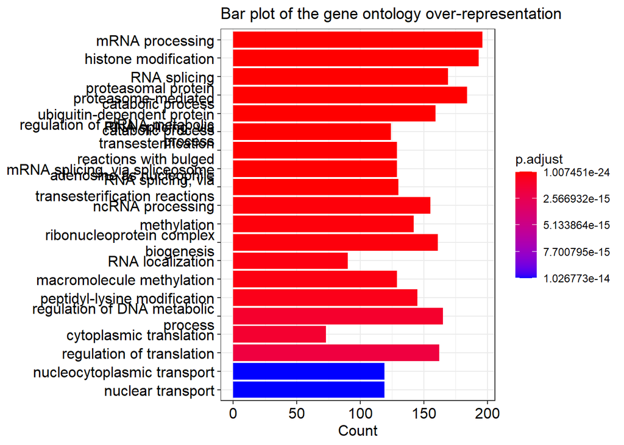

```r
#1. Bar plots
barplot(gobp, showCategory=20) + ggtitle("Bar plot of the gene ontology over-representation")
```

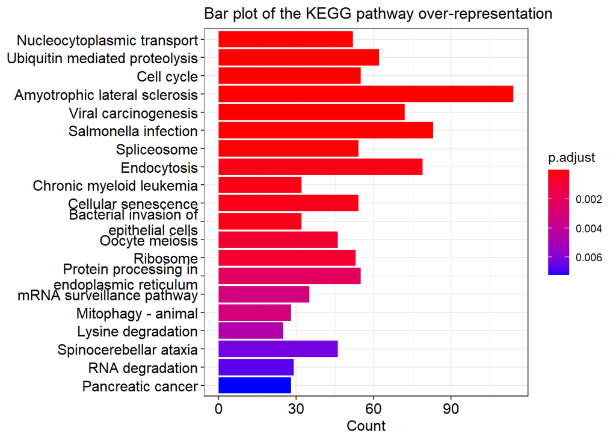

```r
barplot(keggp, showCategory=20) + ggtitle("Bar plot of the KEGG pathway over-representation")
```

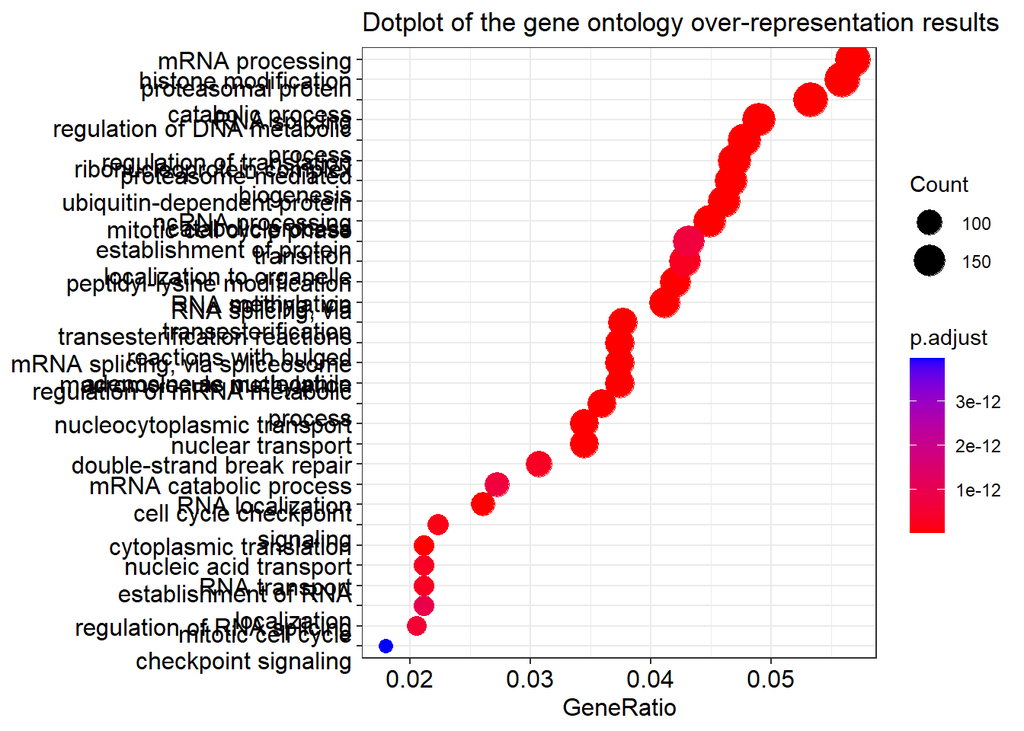

```r
#2. Dot plots
dotplot(gobp, showCategory=30) + ggtitle("Dotplot of the gene ontology over-representation results")
```

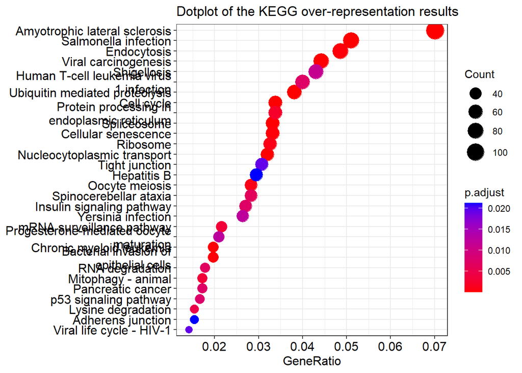

```r
dotplot(keggp, showCategory=30) + ggtitle("Dotplot of the KEGG over-representation results")
```

[figure not shown]

```r
#3. Upset plots showing shared categories by genes
upsetplot(gobp)
```

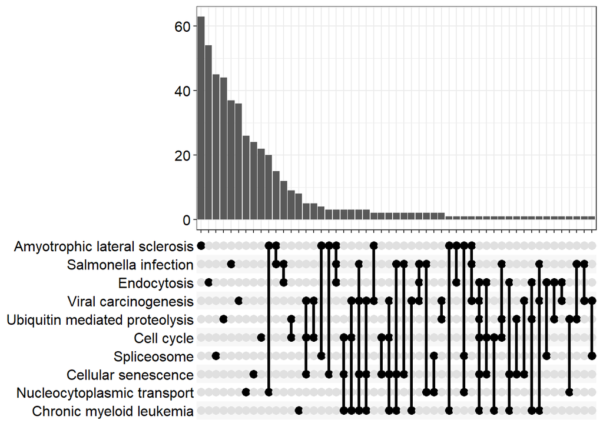

```r
upsetplot(keggp)
```

Plots can be modified using ggplot2, the visualization package in R. Find extensive documentation in the book by Hadley Wickham (https://ggplot2-book.org/).

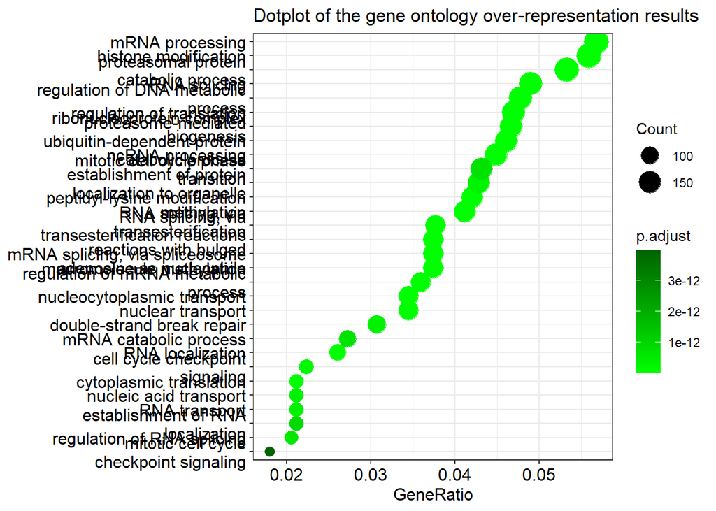

```r
library("ggplot2")

dotplot(gobp, showCategory=30) +
  ggtitle("Dotplot of the gene ontology over-representation results") +
  scale_colour_gradient(low="green", high="darkgreen")
```

Or take control and use `ggplot2` direct on your enrichment results.

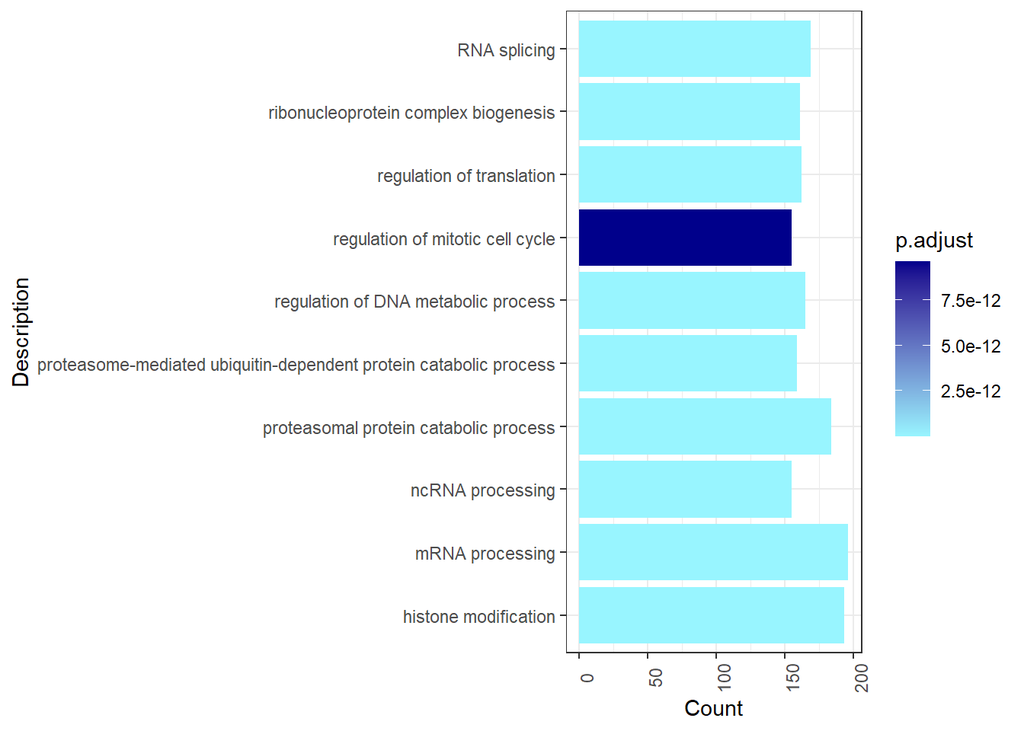

```r
gobp <- as.data.frame(gobp) %>% arrange(desc(Count))
gobp$Description <- factor(gobp$Description)


ggplot(data = gobp[c(1:10),], aes(x = Description, y=Count, fill=p.adjust))+
  geom_bar(stat = "identity")+
  scale_fill_gradient(low="cadetblue1", high="darkblue")+
  coord_flip()+
  theme_bw()+
 theme(axis.text.x = element_text(angle = 90))
```